# NeLD estimates with NeEstimator for microsatellites’ datasets

MGH

2025-07-21

The purpose of this code below is to estimate Ne with LDNe implemented in NeEstimator v2.1 (Waples and Do 2008, Do et al. 2014) for the SSRs datasets ONLY (see another code .Rmd for the SNPs datasets).

For this, we need first to prepare the files, from genind object in R and convert them into genepop files with the extension .txt or .gen.

Then, I will run automatically NeEstimator (not by hand using the GUI) using RLDNe package (from Zach Robinson, https://github.com/zakrobinson/RLDNe). For this, we need first to prepare a parameter file for each genepop file and provided in the package description.

Finally, once NeEstimator is ran, I want to extract the values estimated by LDNe. The output from NeEstimator is not readable by R. So I wrote a function and a code to extract the values from all the different output files and store them in a single table with .csv. This table will allow to analyze easily the results.

# 1 Set-up

```r
library(graph4lg)
library(RLDNe)
library(dartR)

library(dplyr)
library(ggplot2)
library(tidyverse)
```

# 2 Get a genepop file from an R genind object

All my SSRs datasets are stored as genind object (obtained from previous step of my workflow). There is one file by dataset, with the assignation of individuals to population.

I will create genepop files, with one file per population.

```r
full_microsat_files <- list.files("C:/Users/mgharribey/Documents/These_BIOGECO/Article1/analyses_article1/Summary_stats_genetic/Genetic_data_v2/FINAL_datasets/microsat", full.names = TRUE)
#if for one dataset
#i="C:/Users/mgharribey/Documents/These_BIOGECO/Article1/analyses_article1/Summary_stats_genetic/Genetic_data_v2/FINAL_datasets/microsat/genind_Coenagrion_mercuriale_Leveque_2024.Rdata"

for (i in full_microsat_files){
  load(i)
  genind_data_name <- sub("\\.Rdata$", "", basename(i))
  genind_data <- get(genind_data_name)

  genind_data_name2 <- sub("^genind_","",genind_data_name)

  genind_sep <- seppop(genind_data)

  for (pop in names(genind_sep)){
  #first of all - filter singletons and also non polymorphic - FILTERING DID NOT WORK
  #allele_tab <- tab(genind_sep[[pop]])
  #allele_count <- apply(allele_tab, 2, function(x) sum(x > 0, na.rm = TRUE))

  #alleles_to_keep <- allele_count[allele_count != 1]
  #filtered_genind <- genind_sep[[pop]]
  #filtered_genind@tab <- filtered_genind@tab[, alleles_to_keep]

  genind_to_genepop(genind_sep[[pop]],output=paste0("genpop_files/microsat/",genind_data_name2,"_",pop,".txt"))
  }
}
```

!!!!!! BE CAREFUL !!!!!!! !!!!!! Remove the spaces by hand in the files name (see for Canis lupus)

Also there are some datasets with a problem –> see the coding of missing data

I advise to look at least at one file per dataset to make sure that everything is okay Look at the missing data encoding, the number of locus, if there are some issues with the name of individuals…

# 3 Prepare the param files

Look at param_files_NeEstimator.sh. Just lauch the loop corresponding to the case of microsatellite datasets in your local terminal.

RLDNe package (from Zach Robinson, https://github.com/zakrobinson/RLDNe) ask to prepare for parameter files, that corresponds to things you can click when using the GUI of NeEstimator.

Here is an example of the paramater file I used:

1 * LD Method 3 * number of critical values 0.02 0.05 1 * critical allele frequency values 0 *tabular output 1* confidence intervals 0 * 0: Random mating, 1: Monogamy (LD method) 0 * max individual to be processed per pop, 0 for no limit 0 * Pop. range to run, given in pair. No limit if the first = 0 0 * Loc. ranges to run, given in pairs. No limit if the 1st = 0 OUTPUT_FILE * output file name GENPOP_FILE * input file *

The code param_files_NeEstimator.sh allows to replace automatically the OUTPUT_FILE and GENPOP_FILE by the corresponding path and file names of the genepop files to estimate Ne from. One parameter file = one genepop file with one population.

# 4 Run LDNe to have the Ne estimates

```r
full_microsat_files <- list.files("with_NeEstimator/Param_files/microsat", full.names = TRUE)

for (param_file in full_microsat_files) {

     run_LDNe(LDNe_params = param_file)
}
```

To check quickly if it all ran well –> go in the corresponding /Results folder and make sure that every files is of 2ko = one population for each file of result If for example, 1ko files = probably didn’t run –> open the file and check the error

I had so trouble with some individual sampling names that were too long (mostly Ursus arctos dataset) + some NA values that were not well encoded (so modified by hand, mostly Rana arvalis)

# 5 Gather the values in a single tab

```r
#function to extract values in R
extract_values <- function(line) {
  values <- unlist(strsplit(line, "\\s+"))
  values <- values[values != ""]
}
```

If the code below show errors while running –> the problem might come from the previous step when NeEstimator was run

```r
#Path to the files
full_microsat_files <- list.files("with_NeEstimator/Results/microsat", full.names = TRUE) #####TBM x2

# Info about your run of LDNe in NeEstimator
nb_crit_val=4
Filter = c("0,05", "0,02","No_singl","No_filter")
#you could also add monogamy or random mating

#Table where every info is going to be kept
Ne_estim_microsat <- matrix(NA, ncol=9, nrow=0)
colnames(Ne_estim_microsat) <- c("Dataset","Pop","Subset","MAF","NeLD","JK_CI_down","JK_CI_up","Overall_LD_r2","Expected_LD_r2")


for (i in full_microsat_files) {

      text_file=i

      lines <- readLines(text_file)

      #Lines with interesting data
      start_index <- grep("Lowest Allele Frequency Used", lines)
      end_index <- grep("Ending time:", lines)

      #Get interesting lines
      table_lines <- lines[(start_index + 4):(end_index - 4)]

      #Remove lines not interesting
      table_lines <- table_lines[table_lines != ""]

      #Extract values
      estimated_Ne <- extract_values(table_lines[5])
      JK_CI_down <- extract_values(table_lines[9])
      JK_CI_up <- extract_values(table_lines[10])
      Overall_LD_r2 <- extract_values(table_lines[3])
      Expected_LD_r2 <- extract_values(table_lines[4])

      #Store info in a tab
      #Get dataset name
      parts <- strsplit(tools::file_path_sans_ext(basename(text_file)), "_")[[1]]
      Dataset <- paste(parts[1:4], collapse = "_")
      #Population name
      Pop=paste(parts[5:length(parts)], collapse = "_")


      # ADD all this + Ne info for each MAF threshold
      Ne_estim_microsat <- rbind(Ne_estim_microsat,
                                  data.frame(Dataset = rep(Dataset,nb_crit_val),
                                             Pop = rep(Pop,nb_crit_val),
                                             Subset = rep("All_ssrs",nb_crit_val),
                                             MAF = Filter,
                                             NeLD = tail(estimated_Ne, nb_crit_val),
                                             JK_CI_down = tail(JK_CI_down, nb_crit_val),
                                             JK_CI_up = tail(JK_CI_up, nb_crit_val),
                                             Overall_LD_r2 = tail(Overall_LD_r2, nb_crit_val),
                                             Expected_LD_r2 = tail(Expected_LD_r2, nb_crit_val)
                                             ))

}

#cleaning
rm(end_index,start_index,estimated_Ne,JK_CI_down,JK_CI_up,lines,table_lines,text_file)

# get table in good shape
Ne_estim_microsat <- as.data.frame(Ne_estim_microsat) %>%
  mutate(across(c("NeLD","JK_CI_down","JK_CI_up","Overall_LD_r2","Expected_LD_r2"), as.numeric))#careful turn Inf values in NA
```

```r
Ne_estim_microsat$Marker_type <- "microsat"
```

You can chek your newly created dataset

```r
head(Ne_estim_microsat)
```

|  | Dataset | Pop | Subset | MAF | NeLD | JK_CI_down | JK_CI_up | Overall_LD_r2 | Expected_LD_r2 | Marker_type |
| --- | --- | --- | --- | --- | --- | --- | --- | --- | --- | --- |
| 1 | Alytes_obstetricans_Barratt_2024 | MetapopA | All_ssrs | 0,05 | 117.5 | 11.1 | NA | 0.020718 | 0.017932 | microsat |
| 2 | Alytes_obstetricans_Barratt_2024 | MetapopA | All_ssrs | 0,02 | 30.5 | 3.2 | NA | 0.028047 | 0.017848 | microsat |
| 3 | Alytes_obstetricans_Barratt_2024 | MetapopA | All_ssrs | No_singl | 85.4 | 13.9 | NA | 0.021694 | 0.017888 | microsat |
| 4 | Alytes_obstetricans_Barratt_2024 | MetapopA | All_ssrs | No_filter | 85.4 | 17.1 | NA | 0.021694 | 0.017888 | microsat |
| 5 | Alytes_obstetricans_Barratt_2024 | MetapopC | All_ssrs | 0,05 | 14.5 | 2.8 | 557.3 | 0.055816 | 0.037073 | microsat |
| 6 | Alytes_obstetricans_Barratt_2024 | MetapopC | All_ssrs | 0,02 | 15.4 | 2.5 | NA | 0.054850 | 0.036994 | microsat |

```r
Ne_estim_microsat <- Ne_estim_microsat %>%
                        mutate(NeLD=if_else(is.na(NeLD),999999,NeLD),
                               JK_CI_down=if_else(is.na(JK_CI_down),999999,JK_CI_down),
                               JK_CI_up=if_else(is.na(JK_CI_up),999999,JK_CI_up))
```

# 6 Graph and storing of the data

We are going to look for only the No_filter values, that are in fact filtered singletons values

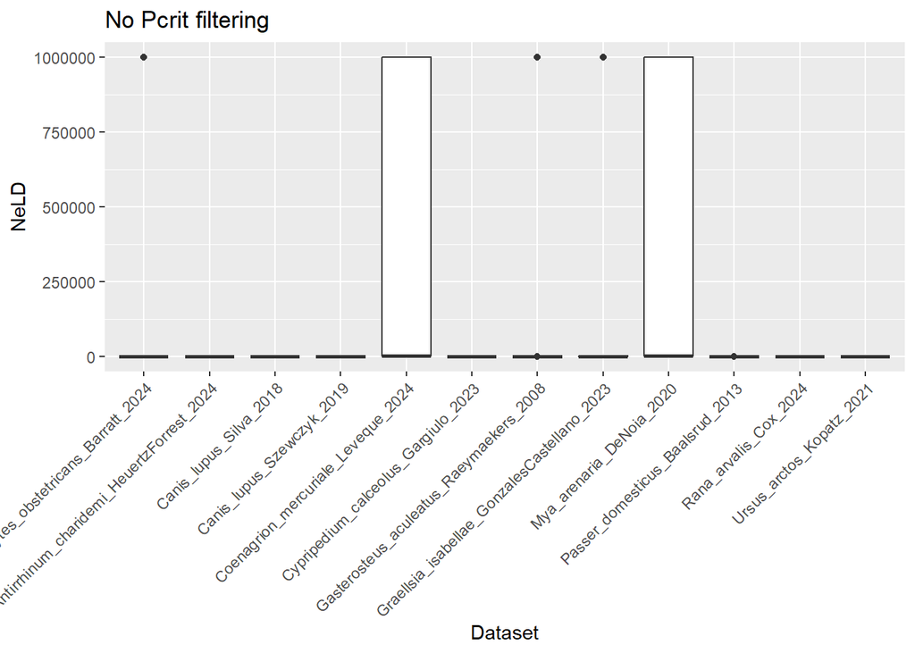

```r
# Quick look at the values
Ne_estim_microsat %>% filter(MAF=="No_filter") %>%
                    ggplot(aes(x=Dataset,y=NeLD))+
  geom_boxplot()+
  theme(axis.text.x = element_text(angle = 45, hjust = 1)) +
  ggtitle("No Pcrit filtering")
```

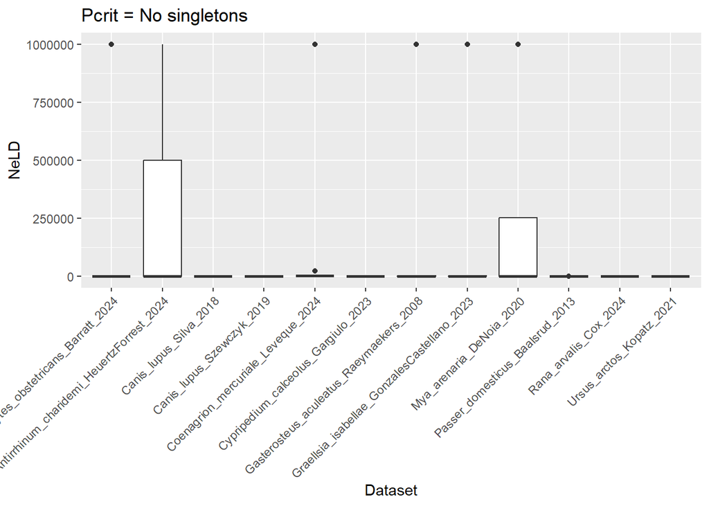

```r
Ne_estim_microsat %>% filter(MAF=="No_singl") %>%
                    ggplot(aes(x=Dataset,y=NeLD))+
  geom_boxplot()+
  theme(axis.text.x = element_text(angle = 45, hjust = 1))+
  ggtitle("Pcrit = No singletons")
```

Save this table to do the analyses on the result later!

```r
write.csv(Ne_estim_microsat %>% filter(MAF=="No_singl"), file="with_NeEstimator/microsat_NeLD_nosingl.csv", row.names = FALSE)

write.csv(Ne_estim_microsat, file="with_NeEstimator/microsat_NeLD_whole_Pcrit.csv", row.names = FALSE)
```